# Practical Machine Learning course project

Yunke Wang

Thursday, April 23, 2015

Using devices such as Jawbone Up, Nike FuelBand, and Fitbit it is now possible to collect a large amount of data about personal activity relatively inexpensively. These type of devices are part of the quantified self movement - a group of enthusiasts who take measurements about themselves regularly to improve their health, to find patterns in their behavior, or because they are tech geeks. One thing that people regularly do is quantify how much of a particular activity they do, but they rarely quantify how well they do it.

The aim of this report was to use data from accelerometers placed on the belt, forearm, arm, and dumbell of six participants to predict how well they were doing the exercise in terms of the classification in the data.

Library import:

```r
library(caret)
```

```r
library(ggplot2)
library(reshape)
library(kernlab)
library(randomForest)
library(knitr)
```

Both training and testing csv files have been added to the current working directory before running the script. Reading the csv file from current working directory for training and processing data.

```r
# read the csv file from current working directory for training
pml_training <- read.csv("pml-training.csv", na.strings = c("NA",""," "))

# clean the data by removing columns with missing values
pml_training_NAs <- apply(pml_training, 2, function(x) {sum(is.na(x))})
pml_training_clean <- pml_training[,which(pml_training_NAs == 0)]

# remove non-relevant columns such as user name and timestamps
pml_training_clean <- pml_training_clean[,-(1:7)]

# split the cleaned testing data into training and cross validation
inTrain <- createDataPartition(y = pml_training_clean$classe, p = 0.80, list = FALSE)
training <- pml_training_clean[inTrain, ]
crossval <- pml_training_clean[-inTrain, ]
```

Plot a correlation matrix for following evaluation

```
##                  X1        X2      value
## 1         roll_belt roll_belt  1.0000000
## 2        pitch_belt roll_belt -0.2156748
## 3          yaw_belt roll_belt  0.8161443
## 4  total_accel_belt roll_belt  0.9809217
## 5      gyros_belt_x roll_belt -0.1181963
## 6      gyros_belt_y roll_belt  0.4684893
## 7      gyros_belt_z roll_belt -0.4551524
## 8      accel_belt_x roll_belt  0.2565304
## 9      accel_belt_y roll_belt  0.9238299
## 10     accel_belt_z roll_belt -0.9919969
```

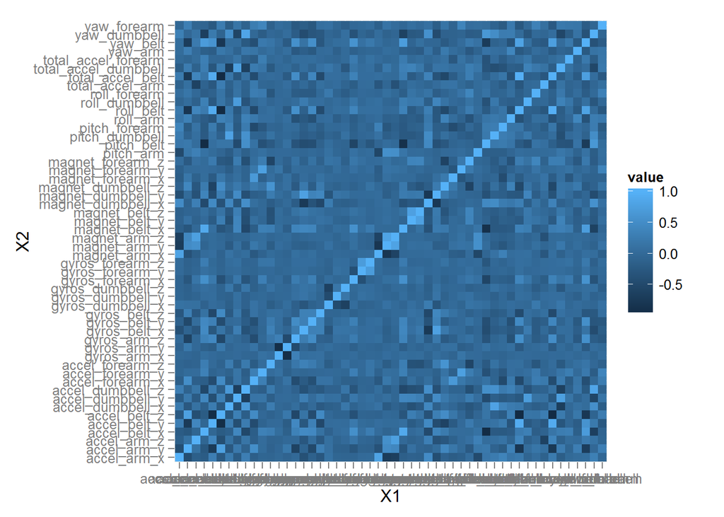

Creating model. The data set was split to 80:20 ratio for training and cross validation. A random forest model has been selected for this project due to its property of balancing error in class unbalanced data sets. The exist of correlation between trees in the forest may increase the forest error rate. According to the previous plot, correlation issue may not have significant impact on the model. This model may yield a 99.6% prediction accuracy.

```r
# fit a model to predict the classe using everything else as a predictor
model <- randomForest(classe ~ ., data = training)

# crossvalidate the model using the remaining 20% of original cleaned training data
predictCrossVal <- predict(model, crossval)
confusionMatrix(crossval$classe, predictCrossVal)
```

```
## Confusion Matrix and Statistics
##
##           Reference
## Prediction    A    B    C    D    E
##          A 1114    1    0    0    1
##          B    0  759    0    0    0
##          C    0    4  680    0    0
##          D    0    0    8  635    0
##          E    0    0    0    1  720
##
## Overall Statistics
##
##                Accuracy : 0.9962
##                  95% CI : (0.9937, 0.9979)
##     No Information Rate : 0.284
##     P-Value [Acc > NIR] : < 2.2e-16
##
##                   Kappa : 0.9952
##  Mcnemar's Test P-Value : NA
##
## Statistics by Class:
##
##                      Class: A Class: B Class: C Class: D Class: E
## Sensitivity            1.0000   0.9935   0.9884   0.9984   0.9986
## Specificity            0.9993   1.0000   0.9988   0.9976   0.9997
## Pos Pred Value         0.9982   1.0000   0.9942   0.9876   0.9986
## Neg Pred Value         1.0000   0.9984   0.9975   0.9997   0.9997
## Prevalence             0.2840   0.1947   0.1754   0.1621   0.1838
## Detection Rate         0.2840   0.1935   0.1733   0.1619   0.1835
## Detection Prevalence   0.2845   0.1935   0.1744   0.1639   0.1838
## Balanced Accuracy      0.9996   0.9967   0.9936   0.9980   0.9992
```

```r
confusionMatrix
```

```
## function (data, ...)
## {
##     UseMethod("confusionMatrix")
## }
## <environment: namespace:caret>
```

Prediction. Implemented the same loading and processing steps on the test raw data. Then, the model was used to predict the classifications results of the test data set.

```r
# apply the same process to prepare test data
pml_test <- read.csv("pml-testing.csv", na.strings = c("NA",""," "))
pml_test_NAs <- apply(pml_test, 2, function(x) {sum(is.na(x))})
pml_test_clean <- pml_test[,which(pml_test_NAs == 0)]
pml_test_clean <- pml_test_clean[,-(1:7)]

# predict the classes of the test data set
predictResult <- predict(model, pml_test_clean)
predictResult
```

```
##  1  2  3  4  5  6  7  8  9 10 11 12 13 14 15 16 17 18 19 20
##  B  A  B  A  A  E  D  B  A  A  B  C  B  A  E  E  A  B  B  B
## Levels: A B C D E
```